# Smash

Authors: Brandt Anzalone, Kyle Reese

Super Smash Brothers Melee (SSBM) is a fighting game released by Nintendo for the Nintendo Gamecube in 2001. Despite its age, SSBM has maintained an active competitive scene throughout most of its lifetime, with recent years seeing some of the highest attendance numbers for tournaments in its competitive history (this can be attributed to a multitude of factors, such as the release of "The Smash Brothers" Documentary and the game's inclusion into the EVO tournament series, the largest annual fighting game tournament in the world). Competitive SSBM tournaments are double elimination brackets with the majority of "sets" being best of three or best of five. Each game in a set consists of two players (who each can pick a character from a roster of 26 possible characteres) each with four lives ("stocks"), who can pick a stage to play on from a specific set of possibles stages. The use of items and other game-influencing mechanics is prohibited throughout the tournament. Unlike most other 2D fighters that feature a health bar that decreases as the player takes damage from attacks, players reaching their demise when the bar reaches zero, SSBM functions completely opposite: Whether a player crosses the borders of the stage (blast zone) determines the death of the player and players are given a percent counter that increases until reaching a hard cap of 999% making them increasingly more likely to hit the blast zone.

Until recently, the majority of statistics related to competitive SSBM have been "high-level", i.e they have mostly involved studying head-to-head matchups of players, winrates of specific players, and winrates of specific characters. While there is much that can be learned from studying these statistics, there is a lack of analysis of in-game statistics. This is analogous to a lack of statistics such as RBI and Batting Average for competitive Baseball analysis. While winning is important, this is very much a "black box" and does little in the way of explanation.

Recent technology - specifically the SmashSight project, which utilizes neural networks to analyze footage of competitive SSBM gameplay in a frame-by-frame manner - allows for the aforementioned in-game analysis. SmashSight specifically takes in footage of competitive SSBM gameplay and returns a comma seperated table containing frame-by-frame readings of each player's stock count and percentages. A frame is 1/60 of a second so this allows for dissecting a match in the most minute details and for conducting smash analysis that is the first of its kind.

In this project we utilize SmashSight's publicly available data of the majority of the top eight sets from the Genesis 5 tournament. A main topic we wish to explore is how winrate is affected via intermediate statistics that we gather from the data: do these statistics linearly correlate to winrate? Is the correlation nonlinear? Do the correlations change when we look at these statistics with regards to players versus when we look at them with regards to characters? Another interesting and fruitful topic we discuss in this project is how holistic judgements about the game are reflected in this data: how do players with holistically categorized playstyles perform statistically? Can we infer a playstyle from a given set of data points? Does Jigglypuff really die early as many have claimed?

```python
import pandas as pd
import numpy as np
import requests
import matplotlib.pyplot as plt
from sklearn.linear_model import LinearRegression
from sklearn.linear_model import SGDRegressor
from sklearn.preprocessing import PolynomialFeatures
from sklearn.neighbors import KNeighborsRegressor
```

The following cell defines the functions we will use to derive our intermediate statistics as well as functions we will use to munge our data. An important detail to note with this is that SmashSight logs its data in a .txt file and in a format for which for which there is no good default parser. As a result, we have written our own called "read_fbf_data".

After the frame by frame data has been worked down, the goal is then to develop statistics that are good indicators of a winning performance. While Smashsight's records may seem light at the moment, we are able to extract a surprising number of variables that are functions of percentage and stocks (SmashSight gives the percentages and stock counts for a player at each frame of the match). For example, some things that SmashSight logs nicely for us is what percent players are dying at. This alone tells us how long a players life has been, in addition to being a simultaneous measure of the opponent's performance. The frame aspect of the measure also gives our data an excellent quantification of time elapsed, which provides insight into actual game flow (the transactions that occurred between two players).

The realization of SmashSight's power comes down to 4 base statistics:

1. Average Death Percent Per Game: The sum of the players death percentages over the number of times they died.
2. Average Kill Percent Per Game: The sum of the players death percentage over the number of times they killed.
3. Average Damage Dealt Per Frame
4. Average Damage Taken Per Frame

and 2 composite statistics:

1. Stock Score: A players average death percentage over their average kill percent (per game)
2. Damage Score: A players damage dealt per frame over a players damage taken per frame (per game)

Analysis of these 6 variables on win rate would hopefully provide meaningful insight on what is making the great players great and how quantification of in-game mechanics can be better predictors than record based statistics.

```python
#These are helper functions to make the data collection process easier

#standardize_name will take in a character name formatted as "Character_Color" and will return "Character"
def standardize_name(char):
    if 'Fox' in char:
        return 'Fox'
    elif 'Sheik' in char:
        return 'Shiek'
    elif 'JigglyPuff' in char:
        return 'JigglyPuff'
    elif 'Peach' in char:
        return 'Peach'
    elif 'Falco' in char:
        return 'Falco'
    elif 'Pikachu' in char:
        return 'Pikachu'
    elif 'Samus' in char:
        return 'Samus'
    else: #should never be reached with this dataset - for a general dataset would need to add an elif for each char
        return 'ERROR'

#Reads in a url for the SmashSight data and parses it
#Returns a dictionary containing the player names, the player chars, the stage, the winner, and a dataframe containing the
#frame-by-frame data for the game
def read_fbf_data(url):
    #Getting the data from the given URL
    data = requests.get(url).text.split('\n')
    #Deleting extraneous rows that are not used
    del data[0]
    del data[1]
    #rows and cols will be used to make the dataframe carrying our data
    rows = []
    cols = ['frame', 'L_Player_dmg', 'R_Player_dmg', 'L_Player_stocks', 'R_Player_stocks']
    #meta_data contains important information about each game that is not predicate on the given frame
    #for instance, player names, characters chosen, and the name of winner is contained in meta_data
    meta_data = data[0].split(',')
    meta_data = [e for e in meta_data if e != 'NA']
    #ret is the dict that we will return
    ret = {}
    L_Player_name = meta_data[1]
    R_Player_name = meta_data[2]
    L_Player_char = standardize_name(meta_data[3])
    R_Player_char = standardize_name(meta_data[4])
    Stage = meta_data[5]
    Winner = ''
    #checking to see which character is listed as the winner and assigning accordingly
    if meta_data[3] in meta_data[6] :
        Winner = L_Player_name
    else:
        Winner = R_Player_name
    ret['L_Player_Name'] = L_Player_name
    ret['R_Player_Name'] = R_Player_name
    ret['L_Player_Char'] = L_Player_char
    ret['R_Player_Char'] = R_Player_char
    ret['Stage'] = Stage
    ret['Winner'] = Winner
    #this for loop generates the dataframe that will contain the frame-by-frame information of the game
    for i in range(1, len(data)):
        row = []
        frame_data = data[i].split(',')
        frame_data = [e for e in frame_data if e !='NA']
        frame = frame_data[0]
        L_Player_dmg = frame_data[1]
        R_Player_dmg = frame_data[2]
        L_Player_stocks = frame_data[3]
        R_Player_stocks = frame_data[4]
        row = [frame, L_Player_dmg, R_Player_dmg, L_Player_stocks, R_Player_stocks]
        rows.append(row)
        #manually adjusting for an extraneous empty line present in one of the datasets
        if url == 'https://smashsight.com/wp-content/uploads/2018/11/genesis-5_axe-VS-mango_4.txt' and frame == '4627':
            break
    df_ret = pd.DataFrame(data=rows, columns = cols)
    ret['game_data'] = df_ret
    return ret

#Converts an array of string representations of integers into an integer array
#i.e given ["1", "2", "3"], it will return [1, 2, 3]
def convert_to_int(arr):
    ret = []
    for ele in arr:
        ret.append(int(ele))

    return ret

def convert_to_float(arr):
    ret = []
    for ele in arr:
        ret.append(float(ele))

    return ret
#returns the frames on which a given player died provided the frame count and an associated stock count at each frame
#i.e if at frame 461 the player has 4 stocks and at frame 462 the player has 3 stocks,
#the number 461 will be returned (among other frame numbers corresp. to other deaths)
def detect_death(frames, stock_count):
    ret = []
    for fr in range(1, len(frames) - 1):
        if(stock_count[fr] > stock_count[fr + 1]):
            ret.append(fr)
    return ret

#returns the percentages that a player died during a game given the game's frame counter and the associated
#stock and damage counter
def find_death_pct(frames, pcts, stocks):
    ret = []
    death_frames = detect_death(frames, stocks)
    for fr in death_frames:
        curr_frame = fr
        while True:
            if int(pcts[curr_frame]) == -1:
                curr_frame = curr_frame - 1
            else:
                break
        ret.append(pcts[curr_frame])
    return ret

#computes the average percents that a player died given a game's frame counter along with the associated
#percentage and stock counts
def compute_avg_death_pct(frames, pcts, stocks):
    avg = 0
    death_pcts = find_death_pct(frames, pcts, stocks)
    for pct in death_pcts:
        avg += pct

    avg /= len(death_pcts)
    return avg

#computes the average percent taken by a player over a given range of frames
def compute_avg_dmg_taken(frame, pcts, start_frame, end_frame):
    avg = 0

    uncounted_frames = 0

    for fr in range(start_frame, end_frame - 1):
        #frames of invulnerability are represented with -1's in the data
        if pcts[fr] == -1 or pcts[fr + 1] == -1:
            uncounted_frames += 1
            continue
        diff = pcts[fr + 1] - pcts[fr] #damage differential per frame
        avg += diff

    #average over the number of frames in the range for which the player CAN take damage
    avg = avg/(end_frame - start_frame - uncounted_frames)
    return avg

#computes the average damage taken by a player over the game
#specifically, finds the average damage taken for each of the player's stocks and then averages
#over the amount of stocks they had
def compute_avg_dmg_taken_per_stock(frames, pcts, stocks):
    death_frames = detect_death(frames, stocks) #getting the frames on which a player died
    avg = 0
    won = False
    #we insert the 0th frame because the functions we use to do the computations require
    #a starting frame and ending frame - put another way, the start frame for each player's
    #first stock is the 0th frame.
    death_frames.insert(0, 0)
    #In the data, the last frame listed is the frame on which the player who lost lost their 4th stock.
    #So for a player who lost and dies 4 times, their death_frames will look like [0, f1, f2, f3, f4].
    #d But for a player who won with, say, 1 stock left, their death_frames will look like [0, f1, f2, f3],
    #and so we cannot directly ditect how many frames they spent on their last stock.
    #In this case we simply append the final frame of the game to the end of the array.
    #We then set won to true to make computations work later on
    if len(death_frames) != 4:
        death_frames.append(frames[len(frames) - 1])
        won = True

    #this loop will get the average damage taken per frame for each of the players stocks
    for i in range(1, len(death_frames) - 1):
        avg += compute_avg_dmg_taken(frames, pcts, death_frames[i - 1], death_frames[i])

    #if the player won or not affects how many extra values we inserted into their death array
    #and so we use this if-else to adjust accordingly
    if won == True:
        avg /= (len(death_frames) - 2)
    else:
        avg /= (len(death_frames) - 1)

    return avg

#computes the stock efficiency of the subject player, defined as avg_death_pct/avg_kill_pct
#tar and sub represent target and subject resp. - this distinction is made because
#of the observation that the percents that player A kills player B is simply the same as
#the death percents player B, and so we use the single function compute_avg_death_pct to find
#the kill/death pcts
def compute_stock_score(frames, tar_pcts, tar_stocks, sub_pcts, sub_stocks):
    avg_kill_pct = compute_avg_death_pct(frames, tar_pcts, tar_stocks)
    avg_death_pct = compute_avg_death_pct(frames, sub_pcts, sub_stocks)
    return (avg_death_pct/avg_kill_pct)

#computes the damage efficiency of a subject player, defined as avg_dmg_dealt/avg_dmg_taken
def compute_dmg_score(frames, tar_pcts, tar_stocks, sub_pcts, sub_stocks):
    avg_dmg_dealt = compute_avg_dmg_taken_per_stock(frames, tar_pcts, tar_stocks)
    avg_dmg_taken = compute_avg_dmg_taken_per_stock(frames, sub_pcts, sub_stocks)
    return (avg_dmg_dealt/avg_dmg_taken)
```

Now that we have defined the helper functions, our next step is to actually gather the data. The data is located in several text files found at https://smashsight.com/download-data/. To parse the text files to get meaningful data we use the helper functions defined above. The specific game data will be stored in the game_fbf_data dictionary, whereas the data associated with specific players and characters will be stored in the player_data and char_data respectively.

```python
#data structures that will house most of our data
game_fbf_data = {}
player_data = {}
char_data = {}

#Gathering data from SmashSight CSV .txt files, collecting the resultant dataframes into a single dictionary
#(one dataframe per game)
game_fbf_data['genesis 5_armada VS leffen_1'] = read_fbf_data('https://smashsight.com/wp-content/uploads/2018/11/genesis-5_armada-VS-leffen_1.txt')
game_fbf_data['genesis 5_armada VS leffen_2'] = read_fbf_data('https://smashsight.com/wp-content/uploads/2018/11/genesis-5_armada-VS-leffen_2.txt')
game_fbf_data['genesis 5_armada VS leffen_3'] = read_fbf_data('https://smashsight.com/wp-content/uploads/2018/11/genesis-5_armada-VS-leffen_3.txt')
game_fbf_data['genesis 5_armada VS leffen_4'] = read_fbf_data('https://smashsight.com/wp-content/uploads/2018/11/genesis-5_armada-VS-leffen_4.txt')
game_fbf_data['genesis 5_armada VS plup_1'] = read_fbf_data('https://smashsight.com/wp-content/uploads/2018/11/genesis-5_armada-VS-plup_1.txt')
game_fbf_data['genesis 5_armada VS plup_2'] = read_fbf_data('https://smashsight.com/wp-content/uploads/2018/11/genesis-5_armada-VS-plup_2.txt')
game_fbf_data['genesis 5_armada VS plup_3'] = read_fbf_data('https://smashsight.com/wp-content/uploads/2018/11/genesis-5_armada-VS-plup_3.txt')
game_fbf_data['genesis 5_leffen VS hbox_1'] = read_fbf_data('https://smashsight.com/wp-content/uploads/2018/11/genesis-5_leffen-VS-hbox_1.txt')
game_fbf_data['genesis 5_leffen VS hbox_2'] = read_fbf_data('https://smashsight.com/wp-content/uploads/2018/11/genesis-5_leffen-VS-hbox_2.txt')
game_fbf_data['genesis 5_leffen VS hbox_3'] = read_fbf_data('https://smashsight.com/wp-content/uploads/2018/11/genesis-5_leffen-VS-hbox_3.txt')
game_fbf_data['genesis 5_leffen VS hbox_4'] = read_fbf_data('https://smashsight.com/wp-content/uploads/2018/11/genesis-5_leffen-VS-hbox_4.txt')
game_fbf_data['genesis 5_leffen VS hbox_5'] = read_fbf_data('https://smashsight.com/wp-content/uploads/2018/11/genesis-5_leffen-VS-hbox_5.txt')
game_fbf_data['genesis 5_armada VS lucky_1'] = read_fbf_data('https://smashsight.com/wp-content/uploads/2018/11/genesis-5_armada-VS-lucky_1.txt')
game_fbf_data['genesis 5_armada VS lucky_2'] = read_fbf_data('https://smashsight.com/wp-content/uploads/2018/11/genesis-5_armada-VS-lucky_2.txt')
game_fbf_data['genesis 5_armada VS lucky_3'] = read_fbf_data('https://smashsight.com/wp-content/uploads/2018/11/genesis-5_armada-VS-lucky_3.txt')
game_fbf_data['genesis 5_hugs VS lucky_1'] = read_fbf_data('https://smashsight.com/wp-content/uploads/2018/11/genesis-5_hugs-VS-lucky_1.txt')
game_fbf_data['genesis 5_hugs VS lucky_2'] = read_fbf_data('https://smashsight.com/wp-content/uploads/2018/11/genesis-5_hugs-VS-lucky_2.txt')
game_fbf_data['genesis 5_hugs VS lucky_3'] = read_fbf_data('https://smashsight.com/wp-content/uploads/2018/11/genesis-5_hugs-VS-lucky_3.txt')
game_fbf_data['genesis 5_axe VS mango_1'] = read_fbf_data('https://smashsight.com/wp-content/uploads/2018/11/genesis-5_axe-VS-mango_1.txt')
game_fbf_data['genesis 5_axe VS mango_2'] = read_fbf_data('https://smashsight.com/wp-content/uploads/2018/11/genesis-5_axe-VS-mango_2.txt')
game_fbf_data['genesis 5_axe VS mango_3'] = read_fbf_data('https://smashsight.com/wp-content/uploads/2018/11/genesis-5_axe-VS-mango_3.txt')
game_fbf_data['genesis 5_axe VS mango_4'] = read_fbf_data('https://smashsight.com/wp-content/uploads/2018/11/genesis-5_axe-VS-mango_4.txt')
game_fbf_data['genesis 5_axe VS mango_5'] = read_fbf_data('https://smashsight.com/wp-content/uploads/2018/11/genesis-5_axe-VS-mango_5.txt')
game_fbf_data['genesis 5_plup VS hbox_1_WF'] = read_fbf_data('https://smashsight.com/wp-content/uploads/2018/11/genesis-5_plup-VS-hbox_1_WF.txt')
game_fbf_data['genesis 5_plup VS hbox_2_WF'] = read_fbf_data('https://smashsight.com/wp-content/uploads/2018/11/genesis-5_plup-VS-hbox_2_WF.txt')
game_fbf_data['genesis 5_plup VS hbox_3_WF'] = read_fbf_data('https://smashsight.com/wp-content/uploads/2018/11/genesis-5_plup-VS-hbox_3_WF.txt')
game_fbf_data['genesis 5_plup VS hbox_4_WF'] = read_fbf_data('https://smashsight.com/wp-content/uploads/2018/11/genesis-5_plup-VS-hbox_4_WF.txt')
game_fbf_data['genesis 5_hbox VS plup_1_GF1'] = read_fbf_data('https://smashsight.com/wp-content/uploads/2018/11/genesis-5_hbox-VS-plup_1_GF1.txt')
game_fbf_data['genesis 5_hbox VS plup_2_GF1'] = read_fbf_data('https://smashsight.com/wp-content/uploads/2018/11/genesis-5_hbox-VS-plup_2_GF1.txt')
game_fbf_data['genesis 5_hbox VS plup_3_GF1'] = read_fbf_data('https://smashsight.com/wp-content/uploads/2018/11/genesis-5_hbox-VS-plup_3_GF1.txt')
game_fbf_data['genesis 5_hbox VS plup_1_GF2'] = read_fbf_data('https://smashsight.com/wp-content/uploads/2018/11/genesis-5_hbox-VS-plup_1_GF2.txt')
game_fbf_data['genesis 5_hbox VS plup_2_GF2'] = read_fbf_data('https://smashsight.com/wp-content/uploads/2018/11/genesis-5_hbox-VS-plup_2_GF2.txt')
game_fbf_data['genesis 5_hbox VS plup_3_GF2'] = read_fbf_data('https://smashsight.com/wp-content/uploads/2018/11/genesis-5_hbox-VS-plup_3_GF2.txt')
game_fbf_data['genesis 5_hbox VS plup_4_GF2'] = read_fbf_data('https://smashsight.com/wp-content/uploads/2018/11/genesis-5_hbox-VS-plup_4_GF2.txt')
game_fbf_data['genesis 5_hbox VS plup_5_GF2'] = read_fbf_data('https://smashsight.com/wp-content/uploads/2018/11/genesis-5_hbox-VS-plup_5_GF2.txt')

for game in game_fbf_data:
    game_fbf_data[game]['game_data']['frame'] = convert_to_int(game_fbf_data[game]['game_data']['frame'])
    game_fbf_data[game]['game_data']['L_Player_dmg'] = convert_to_float(game_fbf_data[game]['game_data']['L_Player_dmg'])
    game_fbf_data[game]['game_data']['L_Player_stocks'] = convert_to_int(game_fbf_data[game]['game_data']['L_Player_stocks'])
    game_fbf_data[game]['game_data']['R_Player_dmg'] = convert_to_float(game_fbf_data[game]['game_data']['R_Player_dmg'])
    game_fbf_data[game]['game_data']['R_Player_stocks'] = convert_to_int(game_fbf_data[game]['game_data']['R_Player_stocks'])
```

```python
#filling the player_data structure with default values of 0 for each player
#i.e after this loop, player_data[player] will be 0
for game in game_fbf_data:
    player_data[game_fbf_data[game]['L_Player_Name']] = 0
    player_data[game_fbf_data[game]['R_Player_Name']] = 0

cols = ['Versus', 'Avg_Death_Pct', 'Avg_Kill_Pct', 'Avg_Dmg_Dealt_Per_Frame', 'Avg_Dmg_Taken_Per_Frame', 'Stock_Score', 'Dmg_Score', 'Player_Char', 'Versus_Char', 'Stage', 'Won']
#this iteration-structure will go find the intermediate statistics we have defined for each player
#by iterating over each game and finding the intermediate statistics from there
for player in player_data:
    rows = []
    for game in game_fbf_data:
        #this if-elif-else structure is necessary because the player name being either
        #the left or right player name affects which values we pass into our helper functions.
        #the actual work being done is identical
        if player == game_fbf_data[game]['L_Player_Name']:
            frames = convert_to_int(game_fbf_data[game]['game_data']['frame'])
            r_player_pcts = convert_to_float(game_fbf_data[game]['game_data']['R_Player_dmg'])
            r_player_stocks = convert_to_int(game_fbf_data[game]['game_data']['R_Player_stocks'])
            l_player_pcts = convert_to_float(game_fbf_data[game]['game_data']['L_Player_dmg'])
            l_player_stocks = convert_to_int(game_fbf_data[game]['game_data']['L_Player_stocks'])
            l_player_char = game_fbf_data[game]['L_Player_Char']
            r_player_char = game_fbf_data[game]['R_Player_Char']

            Won = (player == game_fbf_data[game]['Winner'])
            Versus = game_fbf_data[game]['R_Player_Name']
            Avg_Death_Pct = compute_avg_death_pct(frames, l_player_pcts, l_player_stocks)
            Avg_Kill_Pct = compute_avg_death_pct(frames, r_player_pcts, r_player_stocks)
            Stage = game_fbf_data[game]['Stage']
            Avg_Dmg_Dealt_Per_Frame = compute_avg_dmg_taken_per_stock(frames, r_player_pcts, r_player_stocks)
            Avg_Dmg_Taken_Per_Frame = compute_avg_dmg_taken_per_stock(frames, l_player_pcts, l_player_stocks)
            Stock_Score = compute_stock_score(frames, r_player_pcts, r_player_stocks, l_player_stocks, l_player_stocks)
            Dmg_Score = compute_dmg_score(frames, r_player_pcts, r_player_stocks, l_player_pcts, l_player_stocks)
            rows.append([Versus, Avg_Death_Pct, Avg_Kill_Pct, Avg_Dmg_Dealt_Per_Frame, Avg_Dmg_Taken_Per_Frame, Stock_Score, Dmg_Score, l_player_char, r_player_char, Stage, Won])

        elif player == game_fbf_data[game]['R_Player_Name']:
            frames = convert_to_int(game_fbf_data[game]['game_data']['frame'])
            r_player_pcts = convert_to_float(game_fbf_data[game]['game_data']['R_Player_dmg'])
            r_player_stocks = convert_to_int(game_fbf_data[game]['game_data']['R_Player_stocks'])
            l_player_pcts = convert_to_float(game_fbf_data[game]['game_data']['L_Player_dmg'])
            l_player_stocks = convert_to_int(game_fbf_data[game]['game_data']['L_Player_stocks'])
            l_player_char = game_fbf_data[game]['L_Player_Char']
            r_player_char = game_fbf_data[game]['R_Player_Char']

            Won = (player == game_fbf_data[game]['Winner'])
            Versus = game_fbf_data[game]['L_Player_Name']
            Avg_Death_Pct = compute_avg_death_pct(frames, r_player_pcts, r_player_stocks)
            Avg_Kill_Pct = compute_avg_death_pct(frames, l_player_pcts, l_player_stocks)
            Stage = game_fbf_data[game]['Stage']
            Avg_Dmg_Dealt_Per_Frame = compute_avg_dmg_taken_per_stock(frames, l_player_pcts, l_player_stocks)
            Avg_Dmg_Taken_Per_Grame = compute_avg_dmg_taken_per_stock(frames, r_player_pcts, r_player_stocks)
            Stock_Score = compute_stock_score(frames, l_player_pcts, l_player_stocks, r_player_pcts, r_player_stocks)
            Dmg_Score = compute_dmg_score(frames, l_player_pcts, l_player_stocks, r_player_pcts, r_player_stocks)
            rows.append([Versus, Avg_Death_Pct, Avg_Kill_Pct, Avg_Dmg_Dealt_Per_Frame, Avg_Dmg_Taken_Per_Frame, Stock_Score, Dmg_Score, r_player_char, l_player_char, Stage, Won])

        else: #i.e the player did not play in this game
            continue
    df = pd.DataFrame(data=rows, columns=cols)
    player_data[player] = df
#similarly, setting dummy default values for each character in the character data dictionary
for game in game_fbf_data:
    char_data[game_fbf_data[game]['L_Player_Char']] = 0
    char_data[game_fbf_data[game]['R_Player_Char']] = 0

cols = ['Versus', 'Avg_Death_Pct', 'Avg_Kill_Pct', 'Avg_Dmg_Dealt_Per_Frame', 'Avg_Dmg_Taken_Per_Frame', 'Stock_Score', 'Dmg_Score', 'Stage', 'Won']

#to gather the character data, instead of iterating over each game for each character, we instead iterate over each
#player data table and take the corresponding data from the player data if the player had played the character
#during one of the games (i.e in one of the rows)
for char in char_data:
    rows = []
    for player in player_data:
        for i, row in player_data[player].iterrows():
            if char == row[7]: #if the character was played
                #"stealing" the data from the player table
                rows.append([row[8], row[1], row[2], row[3], row[4], row[5], row[6], row[9], row[10]])
            else:
                continue
    char_table = pd.DataFrame(data = rows, columns = cols)
    char_data[char] = char_table
print(char_data['Fox'])
print(player_data['armada'])
```

```
        Versus  Avg_Death_Pct  Avg_Kill_Pct  Avg_Dmg_Dealt_Per_Frame  \
0          Fox     106.000000    100.000000                 0.091136
1          Fox     115.250000     81.500000                 0.079681
2          Fox     100.250000    126.000000                 0.030858
3          Fox      81.750000     99.000000                 0.041096
4        Shiek      94.000000    112.666667                 0.066128
5        Shiek     123.750000    131.000000                 0.069581
6        Shiek     151.250000    135.000000                 0.040183
7          Fox     100.000000    106.000000                 0.068348
8          Fox      81.500000    115.250000                 0.114124
9          Fox     126.000000    100.250000                 0.050736
10         Fox      99.000000     81.750000                 0.115709
11  JigglyPuff     110.500000    113.666667                 0.028260
12  JigglyPuff      89.000000     90.000000                 0.078793
13  JigglyPuff      75.750000    110.000000                 0.038765
```

[output cut: 101 more lines]

Next we'll want to visualize the data we have prepared. The following code prepares different scatter plots, each looking at a different intermediate statistic versus the observed winrate for each of the top players present in the dataset. An important outlier that must be noted is that of Hugs, a Samus player who did not win a single game during his time in the Genesis 5 Top 8. At the same time that we create the plots, we will also log the values we find so we can conduct meta analysis of the observations in the future and fit a regression line to it. One thing that should be noted is that in all of the cases we are taking the mean of the desired variables for each player in order to create more concise visualizations.

```
[-0.01372378]
```

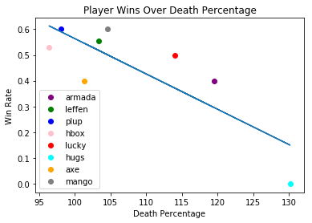

```python
#These colors will represent the different players
color = ["purple", "green", "blue", "pink", "red", "cyan", "orange", "grey"]

#i will iterate through the colors and allow us to add to our dataframe at index
i = 0
fig = plt.figure(1)
#Each of these graphs will feature a dataframe to record the data we create for each stat in the for loop
#DeathPool records the mean of the death percentages for each player
DeathPool = pd.DataFrame(columns=['player','ADP','w'])
#Loops through all players
for player in player_data:
    #Takes the mean of the average death percentage for each player and plots it against their win rate
    plt.scatter(player_data[player]['Avg_Death_Pct'].mean(),player_data[player]['Won'].mean(),c=color[i],label=player)
    plt.xlabel('Death Percentage')
    plt.ylabel('Win Rate')
    plt.title( 'Player Wins Over Death Percentage')
    plt.legend()
    #Creates entry for statistic and increments counter
    DeathPool.loc[i] = [player,player_data[player]['Avg_Death_Pct'].mean(),player_data[player]['Won'].mean()]
    i += 1
#Uses sklearn linear regression for to fit regression line to data
player_death_regression = LinearRegression().fit(DeathPool[['ADP']],DeathPool['w'])
#Creates prediction based on regression for the given data
player_death_prediction = player_death_regression.predict(DeathPool[['ADP']])
#Plots our regression line
plt.plot(DeathPool[['ADP']],player_death_prediction)
#Print the slope of the regression line
print(player_death_regression.coef_)
plt.show()
```

At a holistic level, we can explain some of the observed death percentages by character and stage combinations. For instance, Hugs has a very high average death percentage because Samus, the only character he played, is a relatively heavy character with very good recovery options, meaning that she can survive to higher percents generally. Similarly, we expect to see Hungrybox at a low death percentage because of the incredibly low weight of his main character Jigglypuff (again, meaning she generally dies earlier). Note that this also answers one of the questions we posed above - on average Jigglypuff (whose must successful representation comes from Hungrybox) does indeed die relatively early. In fact, even with Hungrybox's 2nd place performance at the tournament, his average death percentage was still one of the lowest of any players/characters represented in the dataset. However, the definition of "early" in this context is relative - some may claim that Jigglypuff dying early means around 60-70% on average, which is lower than what was observed in this data set.

Also note that the regression line seems somewhat counterintuitive to what one would expect (namely that the longer one lives on average, the more likely they are to win). One possible explanation for this could be that the best players play characters who coincidentally happen to be lighter and will thus die earlier on average. Another possible explanation (which we will explore later) is that the best characters happen to be lighter characters who will die earlier on average. It also should be noted that Hugs' presence is heavily affecting the regression, and thus in a more robust dataset one may see the expted trend of "live longer, win more".

```
[-0.00597272]
```

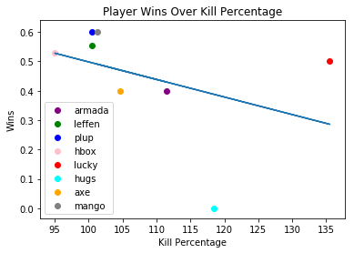

```python
#Plot for win rate over kill percentage
i = 0
fig = plt.figure(2)
#KillPool records the mean kill percentage for each player
KillPool = pd.DataFrame(columns=['AKP','w'])
for player in player_data:
    plt.scatter(player_data[player]['Avg_Kill_Pct'].mean(),player_data[player]['Won'].mean(),c=color[i],label=player)
    plt.xlabel('Kill Percentage')
    plt.ylabel('Wins')
    plt.title( 'Player Wins Over Kill Percentage')
    plt.legend()
    KillPool.loc[i] = [player_data[player]['Avg_Kill_Pct'].mean(),player_data[player]['Won'].mean()]
    i += 1
player_kill_regression = LinearRegression().fit(KillPool[['AKP']],KillPool['w'])
player_kill_prediction = player_kill_regression.predict(KillPool[['AKP']])
plt.plot(KillPool[['AKP']],player_kill_prediction)
print(player_kill_regression.coef_)

plt.show()
```

Wins Over Kill Percentage shows a slight negative correlation between kill percentage win rate. This can be interpreted as the lower the percentage a player can kill his opponent, the more likely they are to win. The coefficient from this plot tells us that for every 1% higher a player killed at, they became -0.6% less likely to win.

Unlike the previous graph and regression, this regression follows what one would expect: the quicker you can kill your opponent, the more likely you are to win. An interesting aspect about this plot is the cluster of Plup, Leffen, and Mango, who all played similar characters for most of the games they played in the data set.

```
[12.28672103]
```

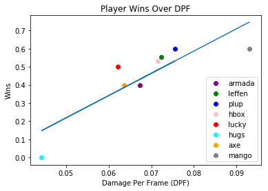

```python
#Plot for win rate over damage per frame
i = 0
fig = plt.figure(3)
#Dataframe for recording the average damage per frame of each player
DamagePool = pd.DataFrame(columns=['DPF','w'])
for player in player_data:
    plt.scatter(player_data[player]['Avg_Dmg_Dealt_Per_Frame'].mean(),player_data[player]['Won'].mean(),c=color[i],label=player)
    plt.xlabel('Damage Per Frame (DPF)')
    plt.ylabel('Wins')
    plt.title( 'Player Wins Over DPF')
    plt.legend(loc=4)
    DamagePool.loc[i] = [player_data[player]['Avg_Dmg_Dealt_Per_Frame'].mean(),player_data[player]['Won'].mean()]
    i += 1
player_dpf_regression = LinearRegression().fit(DamagePool[['DPF']],DamagePool['w'])
player_dpf_prediction = player_dpf_regression.predict(DamagePool[['DPF']])
plt.plot(DamagePool[['DPF']],player_dpf_prediction)
print(player_dpf_regression.coef_)
plt.show()
```

Again this seems to fit our expectations: we expect that as one does more damage over the game, the more likely they are to win. Further, the observed data seems to fit some of our intuitive predictions about the game - for instance Mango, who is known for his hard-hitting combos, has the highest DPF for any of players in the dataset, which is reflective of those hard-hitting combos (brief periods of high sustained damage).

```
[-3.64185382]
```

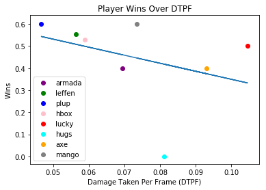

```python
#Plot for win rate over damage taken per frame
i = 0
fig = plt.figure(4)
#Dataframe for recording average damage taken per frame of each player
TakenPool = pd.DataFrame(columns=['DTPF','w'])
for player in player_data:
    plt.scatter(player_data[player]['Avg_Dmg_Taken_Per_Frame'].mean(),player_data[player]['Won'].mean(),c=color[i],label=player)
    plt.xlabel('Damage Taken Per Frame (DTPF)')
    plt.ylabel('Wins')
    plt.title( 'Player Wins Over DTPF')
    plt.legend()
    TakenPool.loc[i] = [player_data[player]['Avg_Dmg_Taken_Per_Frame'].mean(),player_data[player]['Won'].mean()]
    i += 1
player_dtpf_regr = LinearRegression().fit(TakenPool[['DTPF']],TakenPool['w'])
player_dtpf_pred = player_dtpf_regr.predict(TakenPool[['DTPF']])
plt.plot(TakenPool[['DTPF']],player_dtpf_pred)
print(player_dtpf_regr.coef_)
plt.show()
```

Wins Over DTPF is somewhat less clear, although there is some clustering between players that take less damage per frame doing better. The coefficient suffers from previously cited problem that DPF did and is scaled in the same manner yielding that players are 3.6% less likely to win as their DTPF increases.

```
[0.35036971]
```

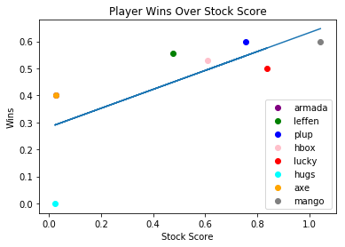

```python
#Plot for win rate over stock score
i = 0
fig = plt.figure(5)
#Dataframe for recording the average stock score for each player
StockPool = pd.DataFrame(columns=['StS','w'])
for player in player_data:
    plt.scatter(player_data[player]['Stock_Score'].mean(),player_data[player]['Won'].mean(),c=color[i],label=player)
    plt.xlabel('Stock Score')
    plt.ylabel('Wins')
    plt.title( 'Player Wins Over Stock Score')
    plt.legend()
    StockPool.loc[i] = [player_data[player]['Stock_Score'].mean(),player_data[player]['Won'].mean()]
    i += 1
player_stock_score_regr = LinearRegression().fit(StockPool[['StS']],StockPool['w'])
player_stock_score_pred = player_stock_score_regr.predict(StockPool[['StS']])
plt.plot(StockPool[['StS']],player_stock_score_pred)
print(player_stock_score_regr.coef_)
plt.show()
```

Wins Over Stock Score appears to be one of our best metrics yet and shows the higher a players stock score, the more guaranteed their winningness. The coefficient tells us that as stock score increases by 1 we become 35% more likely to see that person become the victor! (Recall that a player's stock score is defined to be their average death percentage for a game divided by their average kill percentage for a game).

In the next cell we will also include our meta analysis of the data by regressing over all the variables with respect to win rate.

```
[0.49151344]
```

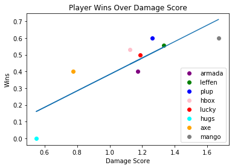

```python
#Plot for win rate over damage score
i = 0
fig = plt.figure(6)
#Dataframe for recording the average damage score for each player
DamPool = pd.DataFrame(columns=['DS','Win Rate'])
for player in player_data:
    plt.scatter(player_data[player]['Dmg_Score'].mean(),player_data[player]['Won'].mean(),c=color[i],label=player)
    plt.xlabel('Damage Score')
    plt.ylabel('Wins')
    plt.title( 'Player Wins Over Damage Score')
    plt.legend()
    DamPool.loc[i] = [player_data[player]['Dmg_Score'].mean(),player_data[player]['Won'].mean()]
    i += 1
player_damage_score_regr = LinearRegression().fit(DamPool[['DS']],DamPool['Win Rate'])
player_damage_score_pred = player_damage_score_regr.predict(DamPool[['DS']])
plt.plot(DamPool[['DS']],player_damage_score_pred)
print(player_damage_score_regr.coef_)
plt.show()
```

Once again damage score is a measure of a type of efficiency - players with high damage scores will have, on average, dealt more damage per frame and taken less damage per frame than others.

Given the individual analysis of these variables, it is reasonable to say that we are on to something with metrics like stock score and damage score. Some interesting things we can pull from the collected data thus far is how Mango has impressively high scores in both of these areas despite his relatively low placement. One possible explanation for this (which will be expanded upon in the limitations sections later on) is that one of the sets that Mango played in this tournament's Top 8 is unaccounted for in the dataset and so his scores may be exaggerated due to him playing very well in the single set given in the dataset.

```python
#Creates dataframe composed of the data we recorded along our plotting journey thanks to
#pandas concatenate.
player_metadata = pd.concat([DeathPool,KillPool,DamagePool,TakenPool,StockPool,DamPool],axis=1)
#Drops extranneous repetitive data
player_metadata = player_metadata.drop(['w'],axis=1)

#Creates a feature matrix and fits regression
player_metadata_feature = player_metadata.drop(['player','Win Rate'],axis=1)
#Linear regression over our player data
player_metadata_regr = LinearRegression().fit(player_metadata_feature,player_metadata['Win Rate'])
#Prints coefficients
print(player_metadata_regr.coef_)
```

```
[-0.01485725  0.00902969  2.18388003 -2.00664632 -0.14469172  0.35677882]
```

Now in reference to the coefficients of our multi-variate regression: Given the coefficients of our regression model we see something unexpected for our previous analysis. A problem appears given the limited scope of the data that we are analyzing. As this is only from one top 8, players who did not win the tournament have a similar win rates to those that did win the tournament. To adjust for this, we could add manual weights to the matches depending on their importance (lateness in the bracket). For instance, winning the entire tournament should count for more than winning a set halfway through the tournament, or even winning a set that happened earlier in the top 8 - The highest weight win would correspond to the grand finals. Another possible solution for scalability and automation purposes is to account for this error in our regression model.

Before we move on to analyze character data, let us examine the results of our player-by-player analyses with regards to the results of the tournament. One promising aspect of these analyses is that for every one of the above plots, Plup, who won the entire tournament, stands at or right near the top of the regression line, with the second and third place finishers (Hungrybox and Leffen respectively) are also clustered near Plup. This reinforces that these intermediate statistics can be used to effectively analyze what differentiates high winrate players from low winrate players.

Now we will use the same intermediate statistics to analyse character-by-character winrates.

```
[0.00691329]
```

[figure not shown]

```python
color = ["purple", "green", "blue", "pink", "red", "cyan", "orange", "grey"]
#This will mirror the example for the player data but with the character data instead
i = 0
fig = plt.figure(1)
#Dataframe for recording the average death percentages for each character
DeathPool2 = pd.DataFrame(columns=['char','ADP','w'])
for char in char_data:
    plt.scatter(char_data[char]['Avg_Death_Pct'].mean(),char_data[char]['Won'].mean(),c=color[i],label=char)
    plt.xlabel('Death Percentage')
    plt.ylabel('Win Rate')
    plt.title( 'Character Wins Over Death Percentage')
    plt.legend()
    DeathPool2.loc[i] = [char,char_data[char]['Avg_Death_Pct'].mean(),char_data[char]['Won'].mean()]
    i += 1
char_death_regr = LinearRegression().fit(DeathPool2[['ADP']],DeathPool2['w'])
char_death_pred = char_death_regr.predict(DeathPool2[['ADP']])
plt.plot(DeathPool2[['ADP']],char_death_pred)
print(char_death_regr.coef_)
```

```
[0.00502548]
```

[figure not shown]

```python
i = 0
fig = plt.figure(2)
#Dataframe for recording average kill percentage for each character
KillPool2 = pd.DataFrame(columns=['AKP','w'])
for char in char_data:
    plt.scatter(char_data[char]['Avg_Kill_Pct'].mean(),char_data[char]['Won'].mean(),c=color[i],label=char)
    plt.xlabel('Kill Percentage')
    plt.ylabel('Wins')
    plt.title( 'Character Wins Over Kill Percentage')
    plt.legend(loc=4)
    KillPool2.loc[i] = [char_data[char]['Avg_Kill_Pct'].mean(),char_data[char]['Won'].mean()]
    i += 1
char_kill_regr = LinearRegression().fit(KillPool2[['AKP']],KillPool2['w'])
char_kill_pred = char_kill_regr.predict(KillPool2[['AKP']])
plt.plot(KillPool2[['AKP']],char_kill_pred)
print(char_kill_regr.coef_)
```

Character kill percentage shows a slight positive correlation between kill percentage and win rate. The coefficient tells us that for every additional percent a player killed at, they were 0.5% more likely to win. While one may expect that we should have a relatively strong negative correlation here, the fact that we are doing this analysis over all the given characters means we must consider each of the character's individual nuances. For instance, one character's "optimal strategy" may not necessarily be to kill eatly but rather to slowly chip away at the other character (and then kill them at a high percent) while evading the other character's attacks.

```
[24.743347]
```

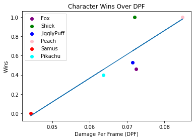

```python
i = 0
fig = plt.figure(3)
#Dataframe for recording the average damage per frame for each character
DamagePool2 = pd.DataFrame(columns=['DPF','w'])
for char in char_data:
    plt.scatter(char_data[char]['Avg_Dmg_Dealt_Per_Frame'].mean(),char_data[char]['Won'].mean(),c=color[i],label=char)
    plt.xlabel('Damage Per Frame (DPF)')
    plt.ylabel('Wins')
    plt.title( 'Character Wins Over DPF')
    plt.legend()
    DamagePool2.loc[i] = [char_data[char]['Avg_Dmg_Dealt_Per_Frame'].mean(),char_data[char]['Won'].mean()]
    i += 1
char_dpf_regr = LinearRegression().fit(DamagePool2[['DPF']],DamagePool2['w'])
char_dpf_pred = char_dpf_regr.predict(DamagePool2[['DPF']])
plt.plot(DamagePool2[['DPF']],char_dpf_pred)
print(char_dpf_regr.coef_)
```

Here we have one of our most strongly correlated statistics as of yet. The correlation tells us that as a character does 0.01 more DPF on average, they are 24% more likely to win the game. This may seem contradictory to the explanation of the weak correlation of the previous plot, but we can see that they are not at odds with each other because no matter how early a character may be trying to kill another character they have to be dealing damage over some rate, and for any strategy the higher that damage rate the better. Note that as one would expect, some of the "heavy hitters" are at the top of the DPF values - importantly Peach, whose moves each do a great deal of damage, sits directly at the top. Sheik, Fox, and Jigglypuff also have relatively strong moves, which explains their position above Pikachu. One may expect Samus to have a higher DPF because she also has strong moves, and with more data this would probably be the case.

```
[-11.20164076]
```

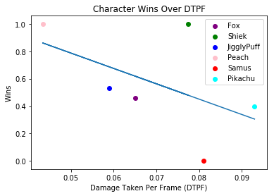

```python
i = 0
fig = plt.figure(4)
#Dataframe for recording the average damage taken per frame for each character
TakenPool2 = pd.DataFrame(columns=['DTPF','w'])
for char in char_data:
    plt.scatter(char_data[char]['Avg_Dmg_Taken_Per_Frame'].mean(),char_data[char]['Won'].mean(),c=color[i],label=char)
    plt.xlabel('Damage Taken Per Frame (DTPF)')
    plt.ylabel('Wins')
    plt.title( 'Character Wins Over DTPF')
    plt.legend()
    TakenPool2.loc[i] = [char_data[char]['Avg_Dmg_Taken_Per_Frame'].mean(),char_data[char]['Won'].mean()]
    i += 1
char_dtpf_regr = LinearRegression().fit(TakenPool2[['DTPF']],TakenPool2['w'])
char_dtpf_pred = char_dtpf_regr.predict(TakenPool2[['DTPF']])
plt.plot(TakenPool2[['DTPF']],char_dtpf_pred)
print(char_dtpf_regr.coef_)
```

Character wins over DTPF shows a relatively strong negative correlation, meaning for every 0.01 more damage taken per frame, a character is -11% less likely to win.

```
[0.40426604]
```

[figure not shown]

```python
i = 0
fig = plt.figure(5)
#Dataframe for recording the average stock score for each character
StockPool2 = pd.DataFrame(columns=['StS','w'])
for char in char_data:
    plt.scatter(char_data[char]['Stock_Score'].mean(),char_data[char]['Won'].mean(),c=color[i],label=char)
    plt.xlabel('Stock Score')
    plt.ylabel('Wins')
    plt.title( 'Character Wins Over Stock Score')
    plt.legend(loc=8)
    StockPool2.loc[i] = [char_data[char]['Stock_Score'].mean(),char_data[char]['Won'].mean()]
    i += 1
char_stock_score_regr = LinearRegression().fit(StockPool2[['StS']],StockPool2['w'])
char_stock_score_pred = char_stock_score_regr.predict(StockPool2[['StS']])
plt.plot(StockPool2[['StS']],char_stock_score_pred)
print(char_stock_score_regr.coef_)
```

[figure not shown]

```
[0.64134296]
```

```python
i = 0
fig = plt.figure(6)
#Dataframe for recording the average damage score for each character
DamPool2 = pd.DataFrame(columns=['DS','Win Rate'])
for char in char_data:
    plt.scatter(char_data[char]['Dmg_Score'].mean(),char_data[char]['Won'].mean(),c=color[i],label=char)
    plt.xlabel('Damage Score')
    plt.ylabel('Wins')
    plt.title( 'Character Wins Over Damage Score')
    plt.legend()
    DamPool2.loc[i] = [char_data[char]['Dmg_Score'].mean(),char_data[char]['Won'].mean()]
    i += 1
char_damage_score_regr = LinearRegression().fit(DamPool2[['DS']],DamPool2['Win Rate'])
char_damage_score_pred = char_damage_score_regr.predict(DamPool2[['DS']])
plt.plot(DamPool2[['DS']],char_damage_score_pred)
plt.show()
print(char_damage_score_regr.coef_)
```

This is a very strongly correlated statistic, and due to the given range of damage scores it is appropriate to say that if a character increases their damage score by 1 then they increase their chance of winning by 64%!

```python
#Repeats the same multi variate prediction process done for the player metadata
char_metadata = pd.concat([DeathPool2,KillPool2,DamagePool2,TakenPool2,StockPool2,DamPool2],axis=1)
char_metadata = char_metadata.drop(['w'],axis=1)
char_metadata_feature = char_metadata.drop(['char'],axis=1)
char_reg = LinearRegression().fit(char_metadata_feature,char_metadata['Win Rate'])
char_reg.coef_
```

```
array([ 4.23860911e-05, -6.96665825e-05,  1.13461613e-02,  4.31668894e-02,
        1.19950372e-03,  1.38853069e-03,  9.98000513e-01])
```

```python
print(player_data['armada'])#Initially shows player data for Armada
#Manually construct the win array using the Genesis 5 bracket here https://smash.gg/tournament/genesis-5/events/melee-singles/brackets/190488/478929
arm_wins = [.8,0,0,0,0,0,0,.75,.75,.75]
#Add array to player data table
player_data['armada']['Adj_Won'] = arm_wins
#Outputs changes for a visual confirm
print(player_data['armada']['Adj_Won'])
```

```
   Versus  Avg_Death_Pct  Avg_Kill_Pct  Avg_Dmg_Dealt_Per_Frame  \
0  leffen     106.000000    100.000000                 0.091136
1  leffen     115.250000     81.500000                 0.079681
2  leffen     100.250000    126.000000                 0.030858
3  leffen      81.750000     99.000000                 0.041096
4    plup      94.000000    112.666667                 0.066128
5    plup     123.750000    131.000000                 0.069581
6    plup     151.250000    135.000000                 0.040183
7   lucky     128.500000     78.500000                 0.100842
8   lucky     149.333333    116.250000                 0.090996
9   lucky     145.000000    134.250000                 0.062740

   Avg_Dmg_Taken_Per_Frame  Stock_Score  Dmg_Score Player_Char Versus_Char  \
0                 0.068348     0.030000   1.333422         Fox         Fox
1                 0.114124     0.030675   0.698195         Fox         Fox
```

[output cut: 31 more lines]

```python
#Rinse and repeat for the remaining players
luck_wins = [0,0,0,.7,.7,.7]
player_data['lucky']['Adj_Won'] = luck_wins


hugs_wins = [0,0,0]
player_data['hugs']['Adj_Won'] = hugs_wins


lef_wins = [0,.8,.8,.8,0,.9,0,.9,0]
player_data['leffen']['Adj_Won'] = lef_wins


hbox_wins = [.9,0,.9,0,.9,.95,0,0,0,1,1,1,1,0,1,0,0]
player_data['hbox']['Adj_Won'] = hbox_wins


plup_wins = [.85,.85,.85,0,.9,.9,.9,0,0,0,0,1,0,1,1]
player_data['plup']['Adj_Won'] = plup_wins


mango_wins = [0,0,.7,.7,.7]
player_data['mango']['Adj_Won'] = mango_wins


axe_wins = [.7,.7,0,0,0]
player_data['axe']['Adj_Won'] = axe_wins
```

```
[-0.0069954]
```

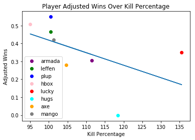

```python
#Plot for win rate over kill percentage
i = 0
fig = plt.figure(2)
#Dataframe for recording average kill percentages for each player with the adjusted win rate
KillPoolT = pd.DataFrame(columns=['AKP','w'])
for player in player_data:
    plt.scatter(player_data[player]['Avg_Kill_Pct'].mean(),player_data[player]['Adj_Won'].mean(),c=color[i],label=player)
    plt.xlabel('Kill Percentage')
    plt.ylabel('Adjusted Wins')
    plt.title( 'Player Adjusted Wins Over Kill Percentage')
    plt.legend()
    KillPoolT.loc[i] = [player_data[player]['Avg_Kill_Pct'].mean(),player_data[player]['Adj_Won'].mean()]
    i += 1
adj_plr_kill_regr = LinearRegression().fit(KillPoolT[['AKP']],KillPoolT['w'])
adj_plr_kill_pred = adj_plr_kill_regr.predict(KillPoolT[['AKP']])
plt.plot(KillPoolT[['AKP']],adj_plr_kill_pred)
print(adj_plr_kill_regr.coef_)

plt.show()
```

```
[9.74454088]
```

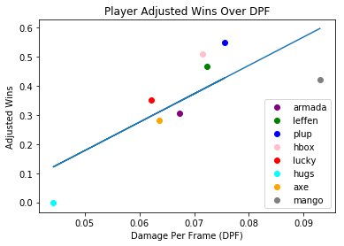

```python
#Plot for win rate over damage per frame
i = 0
fig = plt.figure(3)
#Dataframe for recording average damage per frame for each player with the adjusted win rate
DamagePoolT = pd.DataFrame(columns=['DPF','w'])
for player in player_data:
    plt.scatter(player_data[player]['Avg_Dmg_Dealt_Per_Frame'].mean(),player_data[player]['Adj_Won'].mean(),c=color[i],label=player)
    plt.xlabel('Damage Per Frame (DPF)')
    plt.ylabel('Adjusted Wins')
    plt.title( 'Player Adjusted Wins Over DPF')
    plt.legend(loc=4)
    DamagePoolT.loc[i] = [player_data[player]['Avg_Dmg_Dealt_Per_Frame'].mean(),player_data[player]['Adj_Won'].mean()]
    i += 1
adj_plr_dpf_regr = LinearRegression().fit(DamagePoolT[['DPF']],DamagePoolT['w'])
adj_plr_dpf_pred = adj_plr_dpf_regr.predict(DamagePoolT[['DPF']])
plt.plot(DamagePoolT[['DPF']],adj_plr_dpf_pred)
print(adj_plr_dpf_regr.coef_)
plt.show()
```

```
[-5.1003072]
```

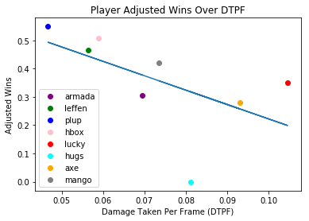

```python
#Plot for win rate over damage taken per frame
i = 0
fig = plt.figure(4)
#Dataframe for recording average damage taken per frame for each player with the adjusted win rate
TakenPoolT = pd.DataFrame(columns=['DTPF','w'])
for player in player_data:
    plt.scatter(player_data[player]['Avg_Dmg_Taken_Per_Frame'].mean(),player_data[player]['Adj_Won'].mean(),c=color[i],label=player)
    plt.xlabel('Damage Taken Per Frame (DTPF)')
    plt.ylabel('Adjusted Wins')
    plt.title( 'Player Adjusted Wins Over DTPF')
    plt.legend()
    TakenPoolT.loc[i] = [player_data[player]['Avg_Dmg_Taken_Per_Frame'].mean(),player_data[player]['Adj_Won'].mean()]
    i += 1
adj_plr_dtpf_regr = LinearRegression().fit(TakenPoolT[['DTPF']],TakenPoolT['w'])
adj_plr_dtpf_pred = adj_plr_dtpf_regr.predict(TakenPoolT[['DTPF']])
plt.plot(TakenPoolT[['DTPF']],adj_plr_dtpf_pred)
print(adj_plr_dtpf_regr.coef_)
plt.show()
```

```
[0.2833365]
```

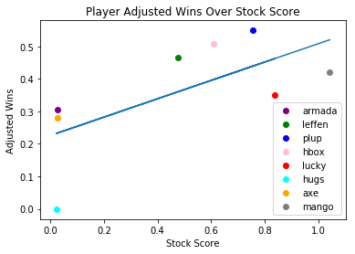

```python
#Plot for win rate over stock score
i = 0
fig = plt.figure(5)
#Dataframe recording the average stock score for each player with adjusted win rate
StockPoolT = pd.DataFrame(columns=['StS','w'])
for player in player_data:
    plt.scatter(player_data[player]['Stock_Score'].mean(),player_data[player]['Adj_Won'].mean(),c=color[i],label=player)
    plt.xlabel('Stock Score')
    plt.ylabel('Adjusted Wins')
    plt.title( 'Player Adjusted Wins Over Stock Score')
    plt.legend()
    StockPoolT.loc[i] = [player_data[player]['Stock_Score'].mean(),player_data[player]['Adj_Won'].mean()]
    i += 1
adj_plr_stock_score_regr = LinearRegression().fit(StockPoolT[['StS']],StockPoolT['w'])
adj_plr_stock_score_pred = adj_plr_stock_score_regr.predict(StockPoolT[['StS']])
plt.plot(StockPoolT[['StS']],adj_plr_stock_score_pred)
print(adj_plr_stock_score_regr.coef_)
plt.show()
```

```
[0.38314152]
```

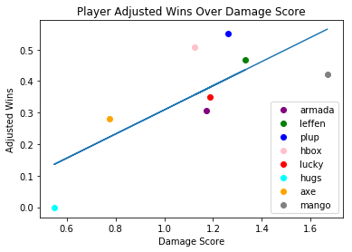

```python
#Plot for win rate over damage score
i = 0
fig = plt.figure(6)
#Dataframe recording the average stock score for each player with adjusted win rate
DamPoolT = pd.DataFrame(columns=['DS','Win Rate'])
for player in player_data:
    plt.scatter(player_data[player]['Dmg_Score'].mean(),player_data[player]['Adj_Won'].mean(),c=color[i],label=player)
    plt.xlabel('Damage Score')
    plt.ylabel('Adjusted Wins')
    plt.title( 'Player Adjusted Wins Over Damage Score')
    plt.legend()
    DamPoolT.loc[i] = [player_data[player]['Dmg_Score'].mean(),player_data[player]['Adj_Won'].mean()]
    i += 1
adj_plr_damage_score_regr = LinearRegression().fit(DamPoolT[['DS']],DamPoolT['Win Rate'])
adj_plr_damage_score_pred = adj_plr_damage_score_regr.predict(DamPoolT[['DS']])
plt.plot(DamPoolT[['DS']],adj_plr_damage_score_pred)
print(adj_plr_damage_score_regr.coef_)
plt.show()
```

```python
#Rinse and repeat of previous metadata multivariate
adj_plr_metadata = pd.concat([DeathPoolT,KillPoolT,DamagePoolT,TakenPoolT,StockPoolT,DamPoolT],axis=1)
adj_plr_metadata = adj_plr_metadata.drop(['w'],axis=1)


#Creates a feature matrix and fits regression
adj_plr_metadata_feature = pd.DataFrame(adj_plr_metadata, columns=['ADP','AKP','DPF','DTPF', 'StS', 'DS'])
adjusted_plr_reg = LinearRegression().fit(adj_plr_metadata_feature,adj_plr_metadata['Win Rate'])
#Prints coefficients
print(adjusted_plr_reg.coef_)
```

```
[-0.01403929  0.00710192 -1.89043788 -4.10009728 -0.07109892  0.27997087]
```

As we can see the trends and regressions are similar for the intermediate statistics measured against the adjusted win rate and the naive win rate. One of the perks of using this adjusted winrate is that it also lessens the effects felt on the analyses of the outlier of Hugs' performance.

Let's recap: so far we have examined the (adjusted and default) winrates over the various intermediate statistics that we defined and both for the various players present in the dataset as well as the various characters present in the dataset. We have fit regression lines to get a rough feel for how these intermediate statistics correlate to our various winrates. What we would now like to do is to take a bit of a deeper dive into using predictive models on this data. SSBM is a complicated game with many factors that contribute to a player's success - given the complex nature of the gameplay of the competitive scene, it very well could be the case that the best way to predict a player's winrate is through nonlinear techniques.

We will now examine two different predictive models: Stochastic Gradient Descent and k-Nearest Neighbors. We will quantify the success of our predictive models by comparing their predictions for our actuals, quantifying what we will refer to as a residual.

```python
#Utilizes scikit learn stochastic gradient descent regressor with a squared loss function
plr_sgd = SGDRegressor(learning_rate='optimal', loss='squared_loss',tol=.1)

#Fits regressor with player metadata feature matrix to player metadata win rate
plr_sgd.fit(player_metadata_feature, player_metadata['Win Rate'])

#Creates prediction for the same data that we trained the model on
plr_sgd_pred = plr_sgd.predict(player_metadata_feature)

#This function will be used to calculate the residual between the predicted value and the actual value
def resi(row):
    return row['Win Rate'] - row['sgd_model_pred']

#Creates new entry for our sgd model in our player metadata
player_metadata['sgd_model_pred'] = plr_sgd_pred

#Creates new entry for the sgd model residual in our player metadata by making use of the
#apply function.
player_metadata['sgd_residual_win'] = player_metadata.apply(lambda row: resi(row),axis=1)

#Prints results
print(player_metadata)
print(plr_sgd.coef_)
```

```
   player         ADP         AKP       DPF      DTPF       StS        DS  \
0  armada  119.508333  111.416667  0.067324  0.069514  0.025830  1.173464
1  leffen  103.305556  100.407407  0.072311  0.056360  0.474696  1.333532
2    plup   98.011111  100.478889  0.075499  0.046706  0.755480  1.261660
3    hbox   96.388235   94.985294  0.071509  0.058913  0.607345  1.125513
4   lucky  114.055556  135.555556  0.062213  0.104547  0.835645  1.186883
5    hugs  130.166667  118.444444  0.044251  0.081058  0.022536  0.548528
6     axe  101.333333  104.566667  0.063616  0.092972  0.028585  0.774578
7   mango  104.566667  101.333333  0.092972  0.073567  1.041413  1.667607

   Win Rate  sgd_model_pred  sgd_residual_win
0  0.400000    1.456701e+17     -1.456701e+17
1  0.555556    1.280919e+17     -1.280919e+17
2  0.600000    1.242703e+17     -1.242703e+17
3  0.529412    1.201967e+17     -1.201967e+17
4  0.500000    1.543714e+17     -1.543714e+17
5  0.000000    1.571066e+17     -1.571066e+17
6  0.400000    1.288046e+17     -1.288046e+17
7  0.600000    1.295216e+17     -1.295216e+17
[ 7.29408728e+14  5.24549337e+14  1.81004913e+12 -2.31246748e+11
  1.97735148e+13  3.86473640e+13]
```

The residuals from the stochastic gradient descent regressor show that the predicted values are astronomically high. This is a terrible predictor because it's saying based on the data that we trained it on, players have an absurdly high chance of winning.

We next attempt k-Nearest Neighbors. We hypothesize that k-Nearest Neighbors will be a relatively strong approach because it can possibly pick out different playstyles in the datasets because they could be clustered closely together.

```python
#Creates a k-nearest neighbors regressor looking at neighborhoods of size 2
#Impericism tells us this will be the best size for our data
kn_regr = KNeighborsRegressor(n_neighbors=2)

#Fits the regressor to our data
kn_regr.fit(player_metadata_feature, player_metadata['Win Rate'])

#Creates predicted values for data we trained on
kn_pred = kn_regr.predict(player_metadata_feature)

#Defines functions to get residual of our second model
def resikn(row):
    return row['Win Rate'] - row['knn_model_pred']

#Add nearest neighbors predicted values to player metadata
player_metadata['knn_model_pred'] = kn_pred

#Creates new entry for the knn model residual in our player metadata by making use of the
#apply function.
player_metadata['knn_residual_win'] = player_metadata.apply(lambda row: resikn(row),axis=1)

#Prints results
print(player_metadata)
```

```
   player         ADP         AKP       DPF      DTPF       StS        DS  \
0  armada  119.508333  111.416667  0.067324  0.069514  0.025830  1.173464
1  leffen  103.305556  100.407407  0.072311  0.056360  0.474696  1.333532
2    plup   98.011111  100.478889  0.075499  0.046706  0.755480  1.261660
3    hbox   96.388235   94.985294  0.071509  0.058913  0.607345  1.125513
4   lucky  114.055556  135.555556  0.062213  0.104547  0.835645  1.186883
5    hugs  130.166667  118.444444  0.044251  0.081058  0.022536  0.548528
6     axe  101.333333  104.566667  0.063616  0.092972  0.028585  0.774578
7   mango  104.566667  101.333333  0.092972  0.073567  1.041413  1.667607

   Win Rate  sgd_model_pred  sgd_residual_win  knn_model_pred  \
0  0.400000    1.456701e+17     -1.456701e+17        0.200000
1  0.555556    1.280919e+17     -1.280919e+17        0.577778
2  0.600000    1.242703e+17     -1.242703e+17        0.577778
3  0.529412    1.201967e+17     -1.201967e+17        0.564706
4  0.500000    1.543714e+17     -1.543714e+17        0.250000
5  0.000000    1.571066e+17     -1.571066e+17        0.200000
6  0.400000    1.288046e+17     -1.288046e+17        0.477778
7  0.600000    1.295216e+17     -1.295216e+17        0.577778

   knn_residual_win
0          0.200000
1         -0.022222
2          0.022222
3         -0.035294
4          0.250000
5         -0.200000
6         -0.077778
7          0.022222
```

The residuals from our second model show that the 2 nearest neighbors are a much better predictor of our data as the residuals are off by < 0.5 rather than an enormous amount, as with SGD. This suggests that along with using linear regression to analyze the intermediate statistics with respect to winrate, we can also use nonlinear approaches - at the very least, we know kNN gives a relatively good predictive model.

There is much future work that can be done using the SmashSight data. One challenge/limitation that we faced with this project was the size of the dataset - while each text file corresponding to each game gives sizeable amounts of frame-by-frame information, there are only a handful of these games provided currently by the SmashSight project. As more tournament games are added to the SmashSight project the results of the analysis done in this project will continue to improve and accuracy and provide much more insight into how these intermediate statistics really do affect winrates across characters and players. Further developments in the technology of SmashSight, such as the addition of data that tracks the position of each character on the screen at each frame, could also allow for exciting new intermediate statistics to be studied - in the case of tracking the position of each character, we could then, for instance, track how often each player controlled the center of the stage during the game, or how effective they were at edge guarding their enemy (making sure the enemy does not get back onto the stage once they are hit off of it). These are all very exciting possibilities, and should usher in a new age of data-science driven analysis of competitive SSBM.